# R4: quanti trascritti cadono nei quadratini di Visium HD nei tessuti veri, e come si dividono fra nucleo, citoplasma e cellule?

geo_spatialtrans, report di step (protocollo v2)

Published

October 30, 2026

## In breve: quanti trascritti cadono nei quadratini di Visium HD nei tessuti veri, e come si dividono fra nucleo, citoplasma e cellule?

**A cosa serviva.** Prima di scrivere la parte del simulatore che mette i trascritti sulla griglia di Visium HD servono valori misurati: quanti trascritti cadono in un quadratino da 2 µm e da 8 µm, quanti quadratini restano vuoti, quanti trascritti ha una cellula, se il nucleo è più o meno denso del citoplasma, se serve un passo che azzera valori a caso («dropout»). La vecchia pipeline usava valori senza fonte: 8 000 trascritti per cellula, un dropout che azzera circa metà dei valori, un tetto a 50 000. Li abbiamo misurati nelle 30 aree di riferimento (5 per tessuto), con i nuclei veri e il tipo cellulare che avevamo dato loro dall’espressione.

**Cosa abbiamo trovato.**

1. **In cinque tessuti su sei le cellule vere hanno da 7 a 100 volte meno trascritti di quanto assumeva la vecchia pipeline, e variano fra loro circa tre volte di più.**
   - Trascritti per cellula (mediana): 83 nel linfonodo, 273 nel cuore, 510 nell’intestino di topo, 800 nello stroma del tumore, 1 125 nel tumore del colon, 6 700 nel cervello di topo.
   - Nessuna cellula supera 50 000 (la più ricca, nel cervello, ne ha 28 000): il tetto della vecchia pipeline non toglieva nulla di vero.
   - Le aree di riferimento non somigliano alla media della sezione intera: nel linfonodo hanno 2.4 volte i trascritti per quadratino della media della sezione, nello stroma 0.6 volte. I valori dei preset vanno presi dalle aree del tessuto, non dai riassunti che 10x pubblica per ogni sezione.
2. **Non serve un passo di dropout: gli zeri si spiegano con le quantità diverse di trascritti fra cellule.**
   - Dentro un tipo cellulare, ogni gene ha tanti zeri quanti ne prevede il modello di conteggio che il simulatore usa già, purché si tenga conto che alcune cellule hanno più trascritti di altre: così nel tumore del colon, nello stroma, nel cervello e nel cuore.
   - Nell’intestino restano zeri in più, ma vengono da sottotipi dentro i tipi grossolani (cellule di Paneth, enterociti in punti diversi del villo, plasmacellule fra le cellule immunitarie), non da perdite tecniche.
   - Nel linfonodo le cellule hanno troppo pochi trascritti per giudicare.
   - Un dropout artificiale del 30 % aggiunto ai dati veri la misura lo vede sempre.
3. **Il nucleo non ha la stessa densità di trascritti del citoplasma in quattro tessuti su sei, e la direzione dipende dal tessuto.**
   - Nel cervello il nucleo ha circa il 40 % di trascritti in più per quadratino rispetto alla corona di 8 µm attorno, nel cuore quasi l’80 % in più; nel tumore del colon il 15 % in meno, nel linfonodo un quinto in meno.
   - Nell’intestino la densità è uniforme; nello stroma la differenza sta a cavallo di un decimo, e vale la densità uniforme come avevamo stabilito per i casi incerti.
   - La prima misura, fatta sui quadratini raggruppati, era disturbata dai compartimenti del tessuto (dove ci sono più nuclei ci sono anche più trascritti); misurata cellula per cellula il disturbo sparisce e le direzioni restano le stesse.
4. **I trascritti per cellula cambiano con il tipo cellulare.** Nel cervello i neuroni ne hanno quasi 4 volte gli oligodendrociti; differenze oltre un quarto anche nell’intestino, nello stroma e nel cuore. Nel tumore del colon e nel linfonodo la misura sta a cavallo della soglia di un quarto (primo punto da decidere).
5. **A 2 µm la griglia di cattura alterna righe e colonne «forti» e «deboli».**
   - Nell’intestino e nel tumore del colon le colonne dispari raccolgono 1.7 volte i trascritti delle pari, nel cervello 1.2, nel linfonodo 1.1; nel cuore l’effetto è minimo e rovesciato.
   - È l’effetto «a strisce» già descritto da chi ha sviluppato Bin2cell. Il reticolo che avevamo visto in un lume del tumore del colon è questo: un altro reticolo, diagonale, non c’è.
   - A 8 µm l’effetto sparisce, perché ogni quadratino da 8 µm contiene metà righe pari e metà dispari.

**Cosa devi decidere.**

1. **Diamo a ogni tipo cellulare il suo numero di trascritti in tutti e sei i tessuti? Consiglio di sì.**
   - In quattro tessuti la differenza fra tipi supera chiaramente un quarto. Nel tumore del colon e nel linfonodo la misura sta a cavallo, e la regola che avevamo scritto prima del calcolo dà allora un solo valore per tessuto.
   - Ma nel tumore del colon le cellule epiteliali tumorali hanno meno di un terzo dei trascritti dell’epitelio normale (373 contro 1 298): restano fuori dal confronto solo perché sono il 4.7 % dei nuclei invece del 5 %.
   - Usare il valore per tipo ovunque non costa nulla: dove i tipi si somigliano, i valori sono vicini.
   - Alternativa: seguire la regola come scritta, un solo valore nel tumore del colon e nel linfonodo. Conseguenza: nel tumore del colon simulato le cellule tumorali avranno circa tre volte i loro trascritti veri.
2. **Il simulatore deve riprodurre a 2 µm l’alternanza di righe e colonne? Consiglio di sì, come strato tecnico che si può spegnere.**
   - I metodi da testare lavorano sempre più a 2 µm, e alcuni (come Bin2cell) correggono proprio queste strisce: senza l’effetto i dati simulati sarebbero più puliti dei veri e quella correzione non si potrebbe mettere alla prova.
   - A 8 µm non cambia nulla.
   - Alternativa: no. Conseguenza: i dati simulati a 2 µm saranno ideali, utili solo per metodi che lavorano a 8 µm o più.

**Comunque**, quando scriveremo il design della griglia: i trascritti per quadratino, per cellula e per tipo misurati qui diventano i riferimenti dei sei tessuti; spariscono il tetto, il dropout e le soglie a memoria della vecchia pipeline; la forza delle strisce si misura sezione per sezione, anche nella parte che non alterna in modo regolare; la densità del nucleo va tarata insieme alla diffusione dei trascritti, che misureremo nello step sulla diffusione, perché togliendo i quadratini al bordo del nucleo la differenza cresce (nel cuore il rapporto passa da 2 a 4); nell’intestino i profili di espressione dovranno avere sottotipi. Gli zeri nel linfonodo restano da giudicare quando avremo cellule con più trascritti.

Appena decidi questi 2 punti, lo step è chiuso.

# Decisioni e verifiche di Luca

- «Approvo tutte e quattro»: ok sulle previsioni P-1…P-4 e sulle soglie (uniforme in [0.909, 1.1]; zeri in eccesso in [-0.02, 0.02]; nessuna cellula sopra 50 000; 1.25 fra tipi), trascritto dalla chat, 2026-10-30.
- Decisione 1, «Sì, valore per tipo in tutti e sei»: ogni tipo cellulare ha il suo numero di trascritti per cellula in tutti i preset, anche nel tumore del colon e nel linfonodo; supera la regola R-3 come scritta (trascritti per tipo e strisce a 2 µm (DEC-035)), 2026-10-30.
- Decisione 2, «Sì, strato tecnico spegnibile»: lo Step 2 riproduce a 2 µm l’alternanza di righe e colonne, con un interruttore (DEC-035), 2026-10-30.

# Dubbi rinviati

| cosa | perché | cosa serve per chiuderlo | step destinatario | voce di BACKLOG |
| --- | --- | --- | --- | --- |
| zeri in eccesso nel linfonodo non valutabili (3 geni con almeno 2 UMI per cellula; con soglia 0.5 il dropout di controllo non è più rilevabile) | le cellule del linfonodo hanno 83 UMI mediani | cellule con più trascritti (impronte più grandi, aggregazione per sottotipo) o un altro stimatore con potenza a medie basse | da assegnare | BL-193 |
| forza delle strisce per riga e colonna a 2 µm oltre l’alternanza pari/dispari (parte non periodica), sezione per sezione; un picco debole fuori dagli assi in una ROI del tumore del colon con 4 tessere | serve per lo strato tecnico dello Step 2 se Luca lo vuole | fattori per riga e per colonna stimati come in Bin2cell, con la loro variabilità fra sezioni | S2.0 | BL-192 |
| la densità del nucleo osservata è sfumata da diffusione e registrazione (senza i bin entro 2 µm dal bordo il rapporto cresce: cuore 2.06 → 3.93, cervello 1.48 → 1.64) | il simulatore genera prima e diffonde dopo: il rapporto da imporre è quello prima della diffusione | taratura congiunta del rapporto nucleo/citoplasma e del raggio di diffusione | R5 | BL-196 |
| sottotipi dentro i tipi grossolani dell’intestino (enterociti zonati, Paneth, plasmacellule) producono zeri in più di quelli previsti dal modello con fattore di taglia | i profili di espressione dello Step 2 per tipo grossolano non li riprodurrebbero | programmi o sottotipi nei profili per tipo | S2.0 | BL-194 |
| la profondità delle ROI differisce dalla media della sezione (da 0.59 a 2.4 volte) | i preset devono dire da quali aree viene la profondità; un utente che vuole «una sezione» ha bisogno della media della sezione | scelta del design dello Step 2 | S2.0 | BL-195 |

# Cancelli

Pre-registrazione: commit `ff04e8f` (cancelli e previsioni), ok di Luca il 2026-10-30 («Approvo tutte e quattro»), commit `e0c2341`. Primo calcolo `9c111a8`; correzioni della revisione e calcolo completo rifatto due volte `fee01a1`.

Cancelli

| id | controllo | esito |
| --- | --- | --- |
| G-1 | batteria di test su dati sintetici e mutanti (`tools/R4_test.py`) | R4_test: 45/45 PASS |
| G-2 | md5 di ogni file reale letto, prima e dopo (`tools/R4_md5.sh`) | G-2 PASS 238 |
| G-3 | lettura dei dati: medie per bin = riassunti 10x; 8 µm = somma dei 16 bin a 2 µm; impronte = R6 (`tools/R4_check.py`) | R4_check: 45/45 PASS |
| G-4 | riproducibilità: seconda esecuzione completa (stadi, analisi, post hoc) in un’altra cartella (`tools/R4_repro.sh`) | G-4 PASS: 14 tabelle identiche |
| G-5 | revisione avversariale: ricalcolo indipendente dei numeri chiave | vedi «Revisione avversariale» |

# Previsioni per tessuto

Intervalli: bootstrap per blocchi sulle 5 ROI per tessuto (a due stadi, ROI e cellule, per le quantità per cellula), B = 2000, seme 20261030; si riporta il 2.5-97.5 % del bootstrap. P-1 e P-4: intervallo atteso nelle colonne «da», «a»; la regola R-1 dice se la densità è uniforme, R-3 se serve un valore per tipo.

Previsioni come scritte (P-4 con la quota dei nuclei come pre-registrato, dopo la correzione RV-1)

| id | tessuto | stima | lo | hi | da | a | esito | regola | note |
| --- | --- | --- | --- | --- | --- | --- | --- | --- | --- |
| P-1 | intestino di topo | 1.0288 | 1.0056 | 1.0471 | 0.909 | 1.10 | confermata | uniforme |  |
| P-1 | tumore del colon | 0.8716 | 0.8469 | 0.8954 | 0.909 | 1.10 | smentita | due densita |  |
| P-1 | stroma del tumore | 0.9694 | 0.9124 | 1.0250 | 0.909 | 1.10 | confermata | uniforme |  |
| P-1 | linfonodo | 0.8006 | 0.7955 | 0.8072 | 0.909 | 1.10 | smentita | due densita |  |
| P-1 | cervello di topo | 1.4816 | 1.4415 | 1.5268 | 1.100 | Inf | confermata | due densita |  |
| P-1 | cuore | 2.0640 | 1.8886 | 2.2394 | 1.100 | Inf | confermata | due densita |  |
| P-2 | intestino di topo | -0.0163 | -0.0222 | -0.0074 | -0.020 | 0.02 | indeterminata |  | 41 geni |
| P-2 | tumore del colon | -0.0262 | -0.0331 | -0.0214 | -0.020 | 0.02 | smentita |  | 69 geni |
| P-2 | stroma del tumore | -0.0165 | -0.0212 | -0.0128 | -0.020 | 0.02 | indeterminata |  | 84 geni |
| P-2 | linfonodo | — | — | — | -0.020 | 0.02 | non valutabile |  | 3 geni |
| P-2 | cervello di topo | 0.0007 | -0.0013 | 0.0038 | -0.020 | 0.02 | confermata |  | 1116 geni |
| P-2 | cuore | -0.0002 | -0.0028 | 0.0016 | -0.020 | 0.02 | confermata |  | 32 geni |
| P-3 | intestino di topo | 0.0000 | 0.0000 | 0.0000 | 0.000 | 0.00 | confermata |  | massimo 5998 UMI |
| P-3 | tumore del colon | 0.0000 | 0.0000 | 0.0000 | 0.000 | 0.00 | confermata |  | massimo 10203 UMI |
| P-3 | stroma del tumore | 0.0000 | 0.0000 | 0.0000 | 0.000 | 0.00 | confermata |  | massimo 10182 UMI |
| P-3 | linfonodo | 0.0000 | 0.0000 | 0.0000 | 0.000 | 0.00 | confermata |  | massimo 1549 UMI |
| P-3 | cervello di topo | 0.0000 | 0.0000 | 0.0000 | 0.000 | 0.00 | confermata |  | massimo 28126 UMI |
| P-3 | cuore | 0.0000 | 0.0000 | 0.0000 | 0.000 | 0.00 | confermata |  | massimo 2218 UMI |
| P-4 | intestino di topo | 1.8328 | 1.7781 | 1.9091 | NA | NA | nessuna attesa | sopra 1.25 | epiteliale;immunitario;stromale e muscolo liscio |
| P-4 | tumore del colon | 1.4487 | 1.2187 | 1.6763 | NA | NA | nessuna attesa | a cavallo di 1.25 | epiteliale normale;fibroblasti |
| P-4 | stroma del tumore | 2.4652 | 2.1907 | 3.1455 | NA | NA | nessuna attesa | sopra 1.25 | endoteliale;epiteliale normale;epiteliale tumorale;fibroblasti;immunitario |
| P-4 | linfonodo | 1.3444 | 1.2143 | 1.4546 | NA | NA | nessuna attesa | a cavallo di 1.25 | linfociti B;linfociti T |
| P-4 | cervello di topo | 3.7612 | 2.4159 | 6.2428 | 1.250 | Inf | confermata | sopra 1.25 | astrociti;neuroni;oligodendrociti |
| P-4 | cuore | 1.6743 | 1.5100 | 2.0095 | 1.250 | Inf | confermata | sopra 1.25 | cardiomiociti;fibroblasti;immunitari |

Una riga per esito: P-1 confermata in 4 tessuti, smentita nel tumore del colon e nel linfonodo nella direzione opposta all’attesa; P-2 confermata in 2, indeterminata in 2, smentita in 1 (zeri in difetto, non in eccesso), non valutabile nel linfonodo; P-3 confermata in 6; P-4 confermata nei 2 tessuti con un’attesa, sopra 1.25 in altri 2, a cavallo in 2.

# Controprove

CP-1: rapporto nucleo/corona con la maschera spostata di 20 µm, atteso in [0.95, 1.05]. CP-2: zeri in eccesso con il 30 % dei valori non nulli azzerati, atteso sopra 0.02

| id | tessuto | stima | lo | hi | esito |
| --- | --- | --- | --- | --- | --- |
| CP-1 | intestino di topo | 1.1660 | 1.1278 | 1.1930 | non superata |
| CP-1 | tumore del colon | 1.0913 | 1.0372 | 1.1701 | non superata |
| CP-1 | stroma del tumore | 1.2593 | 1.1852 | 1.3352 | non superata |
| CP-1 | linfonodo | 1.0088 | 0.9940 | 1.0245 | superata |
| CP-1 | cervello di topo | 1.0522 | 1.0110 | 1.0934 | non superata |
| CP-1 | cuore | 0.9895 | 0.9693 | 1.0106 | superata |
| CP-2 | intestino di topo | 0.0393 | 0.0345 | 0.0453 | superata |
| CP-2 | tumore del colon | 0.0761 | 0.0658 | 0.0880 | superata |
| CP-2 | stroma del tumore | 0.0783 | 0.0747 | 0.0899 | superata |
| CP-2 | linfonodo | — | — | — | non valutabile |
| CP-2 | cervello di topo | 0.1247 | 0.1197 | 0.1331 | superata |
| CP-2 | cuore | 0.1350 | 0.1225 | 0.1509 | superata |

CP-1 non è superata in intestino, tumore, stroma e cervello: il rapporto sui bin raggruppati contiene un effetto di compartimento (le zone fitte di nuclei sono ricche di trascritti anche a 20 µm). Il rapporto pesato per cellula (sotto) ha il nullo a 0.98-1.00 e dà le stesse direzioni: è il riferimento (DEC-034). CP-2 è superata in tutti i tessuti valutabili.

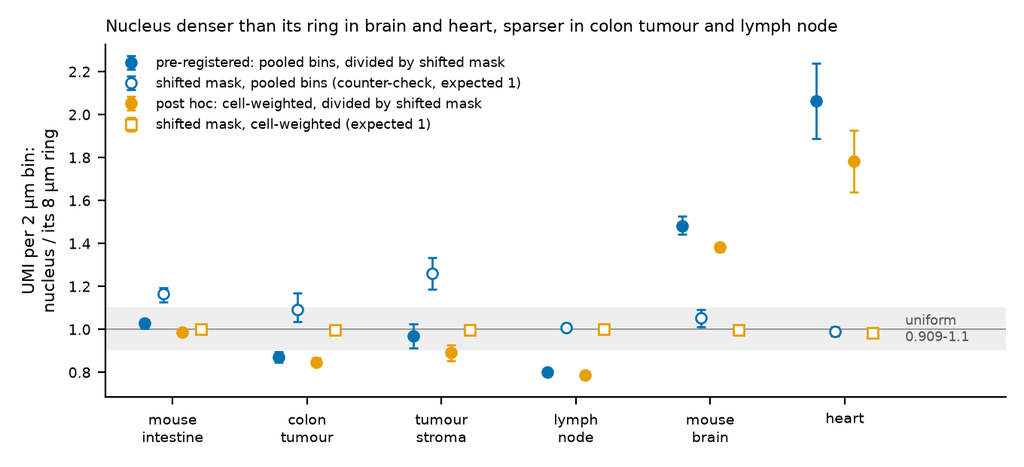

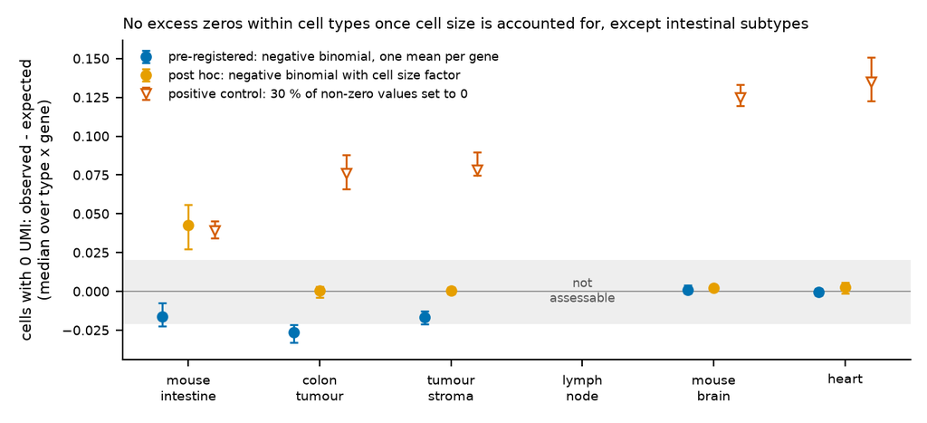

*Cosa guardare*: con il fattore di taglia (arancio) gli zeri in eccesso tornano a 0 in quattro tessuti; resta l’intestino (sottotipi); il controllo con dropout (triangoli) è sempre sopra la banda.

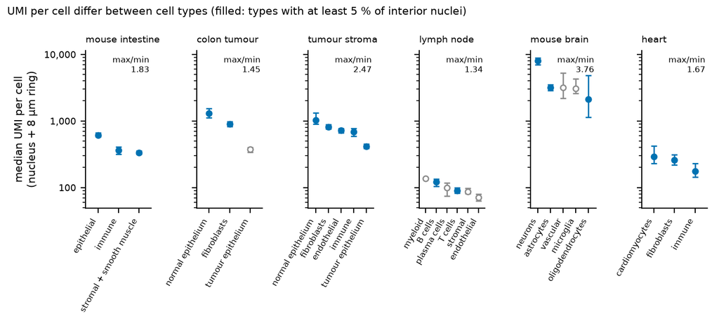

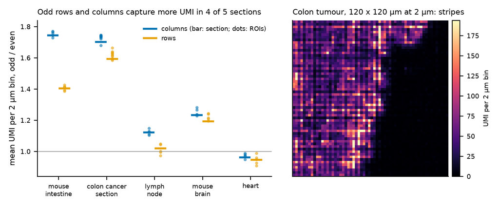

*Cosa guardare*: in quattro sezioni su cinque le colonne e le righe dispari raccolgono più trascritti; le ROI (punti) concordano con la sezione (barre); a destra le strisce verticali nei conteggi a 2 µm.

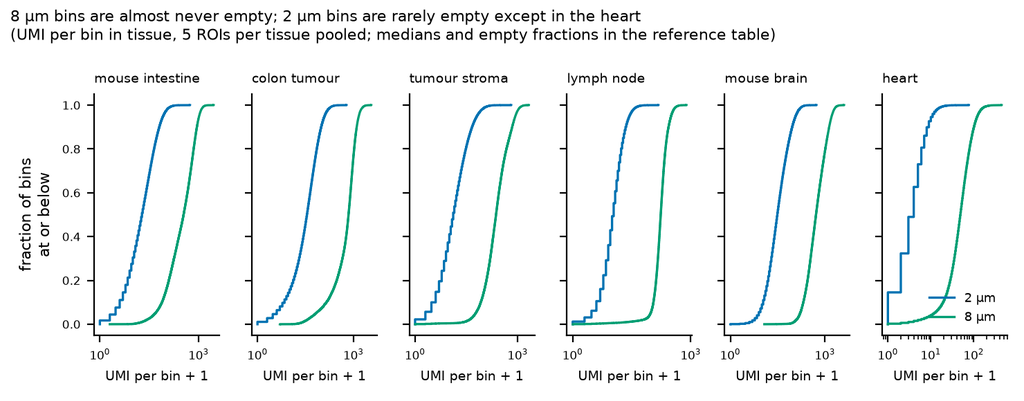

# Analisi post hoc

PH-1: rapporto nucleo/corona pesato per cellula e mediana dei rapporti per cellula, divisi per la maschera spostata; bootstrap sulle ROI

| tessuto | misura | stima | lo | hi | rispetto a 0.909-1.1 |
| --- | --- | --- | --- | --- | --- |
| intestino di topo | cellweighted_shift | 1.002 | 0.998 | 1.005 | confermata |
| intestino di topo | cellweighted_star | 0.986 | 0.975 | 0.997 | confermata |
| intestino di topo | median_cell_ratio_shift | 0.957 | 0.953 | 0.962 | confermata |
| intestino di topo | median_cell_ratio_star | 1.009 | 0.998 | 1.020 | confermata |
| tumore del colon | cellweighted_shift | 0.999 | 0.997 | 1.000 | confermata |
| tumore del colon | cellweighted_star | 0.847 | 0.828 | 0.866 | smentita |
| tumore del colon | median_cell_ratio_shift | 0.980 | 0.975 | 0.987 | confermata |
| tumore del colon | median_cell_ratio_star | 0.862 | 0.839 | 0.884 | smentita |
| stroma del tumore | cellweighted_shift | 0.999 | 0.992 | 1.009 | confermata |
| stroma del tumore | cellweighted_star | 0.892 | 0.854 | 0.928 | indeterminata |
| stroma del tumore | median_cell_ratio_shift | 0.961 | 0.953 | 0.975 | confermata |
| stroma del tumore | median_cell_ratio_star | 0.951 | 0.899 | 1.000 | indeterminata |
| linfonodo | cellweighted_shift | 1.002 | 1.000 | 1.005 | confermata |
| linfonodo | cellweighted_star | 0.788 | 0.772 | 0.803 | smentita |
| linfonodo | median_cell_ratio_shift | 0.993 | 0.988 | 0.999 | confermata |
| linfonodo | median_cell_ratio_star | 0.792 | 0.774 | 0.808 | smentita |
| cervello di topo | cellweighted_shift | 0.996 | 0.990 | 1.002 | confermata |
| cervello di topo | cellweighted_star | 1.383 | 1.362 | 1.402 | smentita |
| cervello di topo | median_cell_ratio_shift | 0.918 | 0.903 | 0.933 | indeterminata |
| cervello di topo | median_cell_ratio_star | 1.523 | 1.490 | 1.555 | smentita |
| cuore | cellweighted_shift | 0.982 | 0.968 | 0.999 | confermata |
| cuore | cellweighted_star | 1.784 | 1.640 | 1.927 | smentita |
| cuore | median_cell_ratio_shift | 0.914 | 0.899 | 0.929 | indeterminata |
| cuore | median_cell_ratio_star | 1.673 | 1.554 | 1.784 | smentita |

PH-2 e PH-3: zeri in eccesso con fattore di taglia per cellula e con soglia 0.5 UMI per cellula, stessi geni e stesso dropout di P-2/CP-2 (obs = dati veri, drop = con dropout del 30 %). Classi non confrontabili con i verdetti di P-2

| tessuto | dati | modello | geni | stima | lo | hi | classe (bootstrap sulle ROI) |
| --- | --- | --- | --- | --- | --- | --- | --- |
| intestino di topo | obs | NB with cell size factor, mean >= 2 | 41 | 0.0425 | 0.0273 | 0.0556 | smentita |
| intestino di topo | obs | NB one mean, mean >= 0.5 | 194 | -0.0028 | -0.0037 | -0.0020 | confermata |
| intestino di topo | obs | NB with cell size factor, mean >= 0.5 | 194 | 0.0123 | 0.0105 | 0.0146 | confermata |
| intestino di topo | drop | NB with cell size factor, mean >= 2 | 25 | 0.1012 | 0.0897 | 0.1125 | smentita |
| intestino di topo | drop | NB one mean, mean >= 0.5 | 118 | 0.0119 | 0.0100 | 0.0128 | confermata |
| intestino di topo | drop | NB with cell size factor, mean >= 0.5 | 118 | 0.0368 | 0.0342 | 0.0398 | smentita |
| tumore del colon | obs | NB with cell size factor, mean >= 2 | 69 | 0.0006 | -0.0040 | 0.0031 | confermata |
| tumore del colon | obs | NB one mean, mean >= 0.5 | 759 | -0.0038 | -0.0047 | -0.0033 | confermata |
| tumore del colon | obs | NB with cell size factor, mean >= 0.5 | 759 | 0.0024 | 0.0011 | 0.0032 | confermata |
| tumore del colon | drop | NB with cell size factor, mean >= 2 | 40 | 0.1296 | 0.1199 | 0.1377 | smentita |
| tumore del colon | drop | NB one mean, mean >= 0.5 | 384 | 0.0089 | 0.0084 | 0.0097 | confermata |
| tumore del colon | drop | NB with cell size factor, mean >= 0.5 | 384 | 0.0230 | 0.0221 | 0.0243 | smentita |
| stroma del tumore | obs | NB with cell size factor, mean >= 2 | 84 | 0.0003 | -0.0017 | 0.0026 | confermata |
| stroma del tumore | obs | NB one mean, mean >= 0.5 | 733 | -0.0029 | -0.0048 | -0.0013 | confermata |
| stroma del tumore | obs | NB with cell size factor, mean >= 0.5 | 733 | 0.0025 | 0.0012 | 0.0034 | confermata |
| stroma del tumore | drop | NB with cell size factor, mean >= 2 | 54 | 0.1244 | 0.1205 | 0.1300 | smentita |
| stroma del tumore | drop | NB one mean, mean >= 0.5 | 405 | 0.0139 | 0.0118 | 0.0156 | confermata |
| stroma del tumore | drop | NB with cell size factor, mean >= 0.5 | 405 | 0.0276 | 0.0259 | 0.0300 | smentita |
| linfonodo | obs | NB with cell size factor, mean >= 2 | 3 | — | — | — | non valutabile |
| linfonodo | obs | NB one mean, mean >= 0.5 | 13 | -0.0239 | -0.0376 | -0.0191 | indeterminata |
| linfonodo | obs | NB with cell size factor, mean >= 0.5 | 13 | -0.0173 | -0.0237 | -0.0053 | indeterminata |
| linfonodo | drop | NB with cell size factor, mean >= 2 | 3 | — | — | — | non valutabile |
| linfonodo | drop | NB one mean, mean >= 0.5 | 7 | — | — | — | non valutabile |
| linfonodo | drop | NB with cell size factor, mean >= 0.5 | 7 | — | — | — | non valutabile |
| cervello di topo | obs | NB with cell size factor, mean >= 2 | 1116 | 0.0021 | 0.0008 | 0.0030 | confermata |
| cervello di topo | obs | NB one mean, mean >= 0.5 | 5332 | 0.0016 | 0.0006 | 0.0027 | confermata |
| cervello di topo | obs | NB with cell size factor, mean >= 0.5 | 5332 | 0.0004 | -0.0001 | 0.0008 | confermata |
| cervello di topo | drop | NB with cell size factor, mean >= 2 | 698 | 0.1457 | 0.1419 | 0.1485 | smentita |
| cervello di topo | drop | NB one mean, mean >= 0.5 | 3990 | 0.0258 | 0.0239 | 0.0276 | smentita |
| cervello di topo | drop | NB with cell size factor, mean >= 0.5 | 3990 | 0.0318 | 0.0296 | 0.0331 | smentita |
| cuore | obs | NB with cell size factor, mean >= 2 | 32 | 0.0026 | -0.0013 | 0.0056 | confermata |
| cuore | obs | NB one mean, mean >= 0.5 | 94 | -0.0004 | -0.0009 | 0.0000 | confermata |
| cuore | obs | NB with cell size factor, mean >= 0.5 | 94 | 0.0041 | -0.0001 | 0.0093 | confermata |
| cuore | drop | NB with cell size factor, mean >= 2 | 21 | 0.1609 | 0.1370 | 0.1723 | smentita |
| cuore | drop | NB one mean, mean >= 0.5 | 66 | 0.0311 | 0.0266 | 0.0371 | smentita |
| cuore | drop | NB with cell size factor, mean >= 0.5 | 66 | 0.0477 | 0.0370 | 0.0521 | smentita |

Intestino: geni con più zeri in eccesso sotto il modello con fattore di taglia (media sulle ROI)

| type | gene | mean | count |
| --- | --- | --- | --- |
| epiteliale | Anpep | 0.146 | 5 |
| epiteliale | Apoa1 | 0.138 | 5 |
| epiteliale | Krt19 | 0.103 | 5 |
| epiteliale | Defa21 | 0.098 | 5 |
| epiteliale | Fabp6 | 0.093 | 5 |
| immunitario | Igkc | 0.091 | 5 |
| epiteliale | Clec2h | 0.084 | 3 |
| immunitario | Igha | 0.084 | 5 |
| epiteliale | Naaladl1 | 0.083 | 5 |
| epiteliale | Lyz1 | 0.083 | 5 |
| immunitario | Jchain | 0.078 | 5 |
| epiteliale | Reg3b | 0.076 | 5 |

Sensibilità: S-1 corona 4 µm, S-2 senza i bin entro 2 µm dal bordo del nucleo, S-3 solo nuclei di forma StarDist, S-4 senza i bin entro 8 µm dal bordo della ROI, intervalli ± 2 e ± t(4) errori standard, P-4 con la quota fra le cellule tipizzate

| tessuto | sensibilità | stima | lo | hi | come P-1 | regola |
| --- | --- | --- | --- | --- | --- | --- |
| intestino di topo | P-1 interval: estimate +- 2 SE (post hoc, review F09) | 1.029 | 1.004 | 1.053 | confermata | uniforme |
| intestino di topo | P-1 interval: estimate +- t(4) SE (post hoc, review F09) | 1.029 | 0.995 | 1.063 | confermata | uniforme |
| intestino di topo | S-1 ring 4 um | 1.001 | 0.980 | 1.018 | confermata | uniforme |
| intestino di topo | S-2 bins >= 2 um from nuclear edge | 1.127 | 1.011 | 1.281 | indeterminata | indeterminata (uniforme per difetto) |
| intestino di topo | S-4 bins >= 8 um from the ROI edge (post hoc, review F15) | 1.027 | 1.004 | 1.045 | confermata | uniforme |
| tumore del colon | P-1 interval: estimate +- 2 SE (post hoc, review F09) | 0.872 | 0.844 | 0.900 | smentita | due densita |
| tumore del colon | P-1 interval: estimate +- t(4) SE (post hoc, review F09) | 0.872 | 0.833 | 0.911 | indeterminata | indeterminata (uniforme per difetto) |
| tumore del colon | S-1 ring 4 um | 0.845 | 0.821 | 0.871 | smentita | due densita |
| tumore del colon | S-2 bins >= 2 um from nuclear edge | 0.858 | 0.831 | 0.883 | smentita | due densita |
| tumore del colon | S-4 bins >= 8 um from the ROI edge (post hoc, review F15) | 0.872 | 0.848 | 0.896 | smentita | due densita |
| tumore del colon | P-4 with the 5 % share among typed cells only (code before review, RV-1/F03) | 3.480 | 2.966 | 4.125 |  | sopra 1.25 |
| stroma del tumore | P-1 interval: estimate +- 2 SE (post hoc, review F09) | 0.969 | 0.908 | 1.031 | indeterminata | indeterminata (uniforme per difetto) |
| stroma del tumore | P-1 interval: estimate +- t(4) SE (post hoc, review F09) | 0.969 | 0.884 | 1.055 | indeterminata | indeterminata (uniforme per difetto) |
| stroma del tumore | S-1 ring 4 um | 0.906 | 0.865 | 0.943 | indeterminata | indeterminata (uniforme per difetto) |
| stroma del tumore | S-2 bins >= 2 um from nuclear edge | 1.030 | 0.944 | 1.105 | indeterminata | indeterminata (uniforme per difetto) |
| stroma del tumore | S-4 bins >= 8 um from the ROI edge (post hoc, review F15) | 0.966 | 0.910 | 1.023 | confermata | uniforme |
| linfonodo | P-1 interval: estimate +- 2 SE (post hoc, review F09) | 0.801 | 0.794 | 0.808 | smentita | due densita |
| linfonodo | P-1 interval: estimate +- t(4) SE (post hoc, review F09) | 0.801 | 0.791 | 0.810 | smentita | due densita |
| linfonodo | S-1 ring 4 um | 0.798 | 0.791 | 0.806 | smentita | due densita |
| linfonodo | S-2 bins >= 2 um from nuclear edge | 0.837 | 0.774 | 0.899 | smentita | due densita |
| linfonodo | S-3 StarDist-shaped nuclei only | 0.784 | 0.775 | 0.792 | smentita | due densita |
| linfonodo | S-4 bins >= 8 um from the ROI edge (post hoc, review F15) | 0.799 | 0.793 | 0.807 | smentita | due densita |
| cervello di topo | P-1 interval: estimate +- 2 SE (post hoc, review F09) | 1.482 | 1.433 | 1.530 | confermata | due densita |
| cervello di topo | P-1 interval: estimate +- t(4) SE (post hoc, review F09) | 1.482 | 1.414 | 1.549 | confermata | due densita |
| cervello di topo | S-1 ring 4 um | 1.224 | 1.198 | 1.255 | confermata | due densita |
| cervello di topo | S-2 bins >= 2 um from nuclear edge | 1.644 | 1.579 | 1.721 | confermata | due densita |
| cervello di topo | S-4 bins >= 8 um from the ROI edge (post hoc, review F15) | 1.490 | 1.448 | 1.532 | confermata | due densita |
| cuore | P-1 interval: estimate +- 2 SE (post hoc, review F09) | 2.064 | 1.853 | 2.275 | confermata | due densita |
| cuore | P-1 interval: estimate +- t(4) SE (post hoc, review F09) | 2.064 | 1.771 | 2.357 | confermata | due densita |
| cuore | S-1 ring 4 um | 1.828 | 1.697 | 1.957 | confermata | due densita |
| cuore | S-2 bins >= 2 um from nuclear edge | 3.929 | 3.322 | 4.611 | confermata | due densita |
| cuore | S-3 StarDist-shaped nuclei only | 2.184 | 2.022 | 2.378 | confermata | due densita |
| cuore | S-4 bins >= 8 um from the ROI edge (post hoc, review F15) | 2.072 | 1.895 | 2.250 | confermata | due densita |

# Dopo il risultato

## Esiti come scritti

- G-1 PASS: `tools/R4_test.py` 45/45 (32 test e 13 mutanti rilevati; i 3 mutanti pre-registrati più 10 aggiunti dopo la revisione). G-2 PASS: 238 file con md5 identico prima e dopo (i 5 file dei nomi dei geni aggiunti dopo la revisione, F14). G-3 PASS 45/45 (`tools/R4_check.py`: medie per bin a 2 e 8 µm uguali ai riassunti 10x a meno di 2e-13 nelle 5 sezioni; 0 bin a 8 µm diversi dalla somma dei loro 16 bin a 2 µm; impronte identiche a R6 in 30/30 ROI). G-4 PASS: 14 tabelle identiche fra due esecuzioni complete (stadi, analisi e post hoc). G-5: due revisori, sotto.
- P-1: confermata in intestino, stroma, cervello, cuore; smentita in tumore del colon (0.872) e linfonodo (0.801), nella direzione opposta all’attesa (nucleo meno denso). Regola R-1: uniforme in intestino e stroma, due densità negli altri quattro.
- CP-1 non superata in intestino (1.166), tumore (1.091), stroma (1.259), cervello (1.052): il rapporto sui bin raggruppati contiene un effetto di compartimento. Spiegata da PH-1 (sotto).
- P-2: confermata in cervello e cuore; indeterminata in intestino e stroma; smentita in tumore del colon (-0.026, zeri in difetto); non valutabile nel linfonodo (3 geni). CP-2 superata nei 5 tessuti valutabili.
- P-3: confermata in tutti (0 cellule sopra 50 000; massimo 28 126 nel cervello). Insieme delle cellule: tutte le cellule tenute, anche al bordo (scelta conservativa: le impronte al bordo sono troncate; revisione F05).
- P-4: confermata in cervello (3.76) e cuore (1.67); sopra 1.25 in intestino (1.83) e stroma (2.47); a cavallo in tumore del colon (1.449 [1.219, 1.676]) e linfonodo (1.344 [1.214, 1.455]). Regola R-3: un valore per tipo in quattro tessuti, uno solo in tumore e linfonodo (decisione 1 a Luca).

## Scelte decise dai dati e deviazioni dichiarate

- Riferimento del rapporto nucleo/citoplasma per lo Step 2: il rapporto pesato per cellula di PH-1 (nullo 0.98-1.00 in tutti i tessuti), con il rapporto pre-registrato come sensibilità: Rapporto nucleo/citoplasma pesato per cellula come riferimento (DEC-034). Le classi della regola R-1 non cambiano.
- P-4: la prima esecuzione calcolava la quota del 5 % sulle sole cellule tipizzate; la pre-registrazione dice «dei nuclei». Corretto dopo la revisione (RV-1, F03); la versione precedente è in `results/R4/R4_sensitivity.csv` (tumore del colon 3.48, sopra 1.25).
- Il comando di G-3 (`tools/R4_check.py`) mancava alla prima esecuzione: il controllo era calcolato dagli stadi; aggiunto (F04).

## Analisi post hoc (dichiarate dopo i risultati)

- PH-1 (CP-1): rapporto nucleo/corona pesato per cellula (media per cellula della densità nel nucleo diviso media per cellula della densità nella corona) e mediana dei rapporti per cellula, ciascuno diviso per lo stesso con la maschera spostata. Il nullo pesato per cellula vale 0.98-1.00; le direzioni sono quelle di P-1 in tutti i tessuti (intestino 0.986, tumore 0.847, stroma 0.892, linfonodo 0.788, cervello 1.383, cuore 1.784). Il nome «appaiato» della prima versione era sbagliato (F08).
- PH-2 (P-2): binomiale negativa con fattore di taglia per cellula, sugli stessi geni e sullo stesso dropout di P-2 e CP-2. Zeri in eccesso ≈ 0 in tumore, stroma, cervello, cuore; +0.04 nell’intestino, dai marcatori di sottotipi (Anpep, Apoa1, Fabp6, Defa21, Lyz1, Reg3b; Igkc, Igha, Jchain fra le immunitarie; stromali 0.0001; `results/R4/R4_PH2_A1_genes.csv`). Il revisore del codice ha mostrato per simulazione che la statistica pre-registrata è spostata verso il negativo quando le cellule hanno quantità diverse di trascritti (-0.034…-0.005 senza alcun dropout) e che lo stimatore con fattore di taglia non lo è (F06). Bootstrap sulle sole ROI: le classi non si confrontano con i verdetti di P-2.
- PH-3 (linfonodo): soglia 0.5 UMI per cellula. 13 geni, ma il dropout di controllo non ha più geni sufficienti (7): non valutabile.
- PH-4 (D-5): alternanza della cattura per parità di riga e colonna della griglia a 2 µm, sezione per sezione e ROI per ROI (media raggruppata).
- Sensibilità aggiunte dopo la revisione: S-4 (bin a ≥ 8 µm dal bordo della ROI, F15) e intervallo ± 2 e ± t(4) errori standard per P-1 (F09). Cambiano classe solo il tumore del colon con ± t(4) (indeterminata) e lo stroma con ± 2 e ± t(4) (indeterminata, uniforme per difetto): nessuna decisione cambia.

## Revisione avversariale

Due revisori indipendenti, in sola lettura sul repo. Il revisore numerico ha ricalcolato da zero (codice proprio, senza le funzioni del progetto) 935 numeri: identici tutti salvo P-4 nel tumore del colon (RV-1, deviazione, corretta), le quote «altro nucleo» e «acellulare» (definizione diversa, somma identica, RV-3) e i rapporti di parità (peso dei quadranti, scarti ≤ 2.2e-5, ora media raggruppata, RV-2). Il revisore del codice ha trovato 2 bug (lo spettro non guardava la frequenza di Nyquist, F01; lo script di riproduzione non includeva il post hoc, F02), 3 deviazioni (F03-F05), 1 discrepanza (F07) e 11 note; i suoi limiti dichiarati: strati ricalcolati da zero su 5 ROI su 30, simulazione degli zeri provvisoria (300 geni, 3 repliche), spettri delle ROI non ricalcolati, G-4 non osservato. Correzioni: F01 (Nyquist incluso, ricerca fuori dagli assi per il reticolo diagonale, F16), F02, F03, F04, F07, F08, F10 (10 mutanti nuovi, tutti rilevati), F14, F15; dopo le correzioni l’intero calcolo è stato rifatto due volte (G-4). I numeri corretti coincidono con quelli dei revisori: P-4 tumore 1.449 [1.219, 1.676]; sfondo dell’intestino a Nyquist 24.1.

## Errori di pre-registrazione

- La statistica di P-2 (binomiale negativa con una sola media per gene) non vale 0 senza dropout quando le cellule hanno quantità diverse di trascritti: la soglia ±0.02 confonde il difetto di zeri dovuto alle taglie con l’assenza di dropout. P-2 resta giudicata come scritta; la lettura pertinente è PH-2.
- La regola di D-5 (un solo picco, il più alto) non poteva separare un reticolo diagonale dall’alternanza di righe e colonne; dopo la revisione si riporta anche il picco fuori dagli assi.

# Cosa è girato

Server lesexp-server, `.venv` del progetto (Python 3.12, numpy, scipy, pandas, h5py). Stadi: `tools/R4_roi.py` (5 processi, uno per sezione), `tools/R4_section.py` (5), `tools/R4_posthoc.py roi` (5), `tools/R4_analysis.py`, `tools/R4_posthoc.py summary`; tutto con `tools/R4_run.sh`. Uscite: `/mnt/micron/geo_spatialtrans/R4/run1` (e `run2` per G-4; `run1_prereview` e `run2_prereview` = calcolo prima delle correzioni). Seme 20261030 (per ROI: [20261030, indice della ROI, 1|2]); B = 2000. Durata: stadio per ROI 3-8 minuti per sezione, analisi circa 2 minuti, calcolo completo circa 10 minuti con 10 processi. Figure: `tools/R4_figures.py`. Righe di BIO_REFERENCES: `tools/R4_bio_rows.py`.

# Appendice

Riferimenti descrittivi D-1…D-3 (media delle ROI o mediana per cellula)

| tessuto | quantità | stima | lo | hi |
| --- | --- | --- | --- | --- |
| intestino di topo | rho_obs nucleus/ring UMI per bin (uncorrected) | 1.199e+00 | 1.167e+00 | 1.233e+00 |
| intestino di topo | mean_umi2 | 2.714e+01 | 2.580e+01 | 2.849e+01 |
| intestino di topo | median_umi2 | 1.820e+01 | 1.740e+01 | 1.900e+01 |
| intestino di topo | q90_umi2 | 6.280e+01 | 5.980e+01 | 6.580e+01 |
| intestino di topo | q99_umi2 | 1.292e+02 | 1.220e+02 | 1.364e+02 |
| intestino di topo | cv_umi2 | 1.028e+00 | 1.019e+00 | 1.038e+00 |
| intestino di topo | frac_empty2 | 1.695e-02 | 1.420e-02 | 1.970e-02 |
| intestino di topo | mean_umi8 | 4.248e+02 | 4.051e+02 | 4.444e+02 |
| intestino di topo | median_umi8 | 3.514e+02 | 3.320e+02 | 3.682e+02 |
| intestino di topo | q90_umi8 | 8.862e+02 | 8.372e+02 | 9.352e+02 |
| intestino di topo | q99_umi8 | 1.323e+03 | 1.252e+03 | 1.393e+03 |
| intestino di topo | cv_umi8 | 7.635e-01 | 7.516e-01 | 7.796e-01 |
| intestino di topo | frac_empty8 | 0.000e+00 | 0.000e+00 | 0.000e+00 |
| intestino di topo | mean_genes2 | 2.520e+01 | 2.403e+01 | 2.638e+01 |
| intestino di topo | mean_genes8 | 3.238e+02 | 3.106e+02 | 3.365e+02 |
| intestino di topo | sparsity2 | 9.987e-01 | 9.986e-01 | 9.987e-01 |
| intestino di topo | sparsity8 | 9.830e-01 | 9.823e-01 | 9.837e-01 |
| intestino di topo | share_nucleus | 1.408e-01 | 1.378e-01 | 1.441e-01 |
| intestino di topo | share_ring | 6.153e-01 | 6.061e-01 | 6.252e-01 |
| intestino di topo | share_acellular | 2.267e-01 | 2.155e-01 | 2.396e-01 |
| intestino di topo | share_other_nucleus | 1.721e-02 | 1.239e-02 | 2.203e-02 |
| intestino di topo | mean_umi2_nucleus | 3.699e+01 | 3.440e+01 | 3.953e+01 |
| intestino di topo | mean_umi2_ring | 3.084e+01 | 2.893e+01 | 3.249e+01 |
| intestino di topo | mean_umi2_acellular | 1.177e+01 | 1.105e+01 | 1.253e+01 |
| intestino di topo | frac_empty2_nucleus | 1.023e-03 | 7.638e-04 | 1.274e-03 |
| intestino di topo | frac_empty2_ring | 4.203e-03 | 3.660e-03 | 4.636e-03 |
| intestino di topo | frac_empty2_acellular | 6.134e-02 | 5.097e-02 | 7.152e-02 |
| intestino di topo | cell_umi_median | 5.100e+02 | 4.790e+02 | 5.430e+02 |
| intestino di topo | cell_umi_q01 | 7.700e+01 | 7.200e+01 | 8.400e+01 |
| intestino di topo | cell_umi_q99 | 2.247e+03 | 2.073e+03 | 2.438e+03 |

[output cut: 168 more lines]

UMI per cellula per tipo (cellule interne)

| tessuto | tipo | quota | cellule | nel confronto | UMI per cellula | lo | hi | UMI per bin |
| --- | --- | --- | --- | --- | --- | --- | --- | --- |
| intestino di topo | epiteliale | 0.684 | 24618 | True | 614.0 | 576.0000 | 660.0000 | 38.879 |
| intestino di topo | immunitario | 0.100 | 3608 | True | 365.0 | 318.9750 | 405.0000 | 33.000 |
| intestino di topo | stromale e muscolo liscio | 0.216 | 7757 | True | 335.0 | 318.4875 | 355.0000 | 16.871 |
| tumore del colon | epiteliale normale | 0.666 | 20229 | True | 1298.0 | 1115.0000 | 1533.0500 | 56.444 |
| tumore del colon | epiteliale tumorale | 0.047 | 1441 | False | 373.0 | 340.9875 | 398.0125 | 43.750 |
| tumore del colon | fibroblasti | 0.201 | 6111 | True | 896.0 | 827.5000 | 977.0000 | 29.692 |
| stroma del tumore | endoteliale | 0.082 | 1581 | True | 725.0 | 661.9875 | 774.0000 | 20.340 |
| stroma del tumore | epiteliale normale | 0.327 | 6342 | True | 1028.0 | 893.0000 | 1330.0250 | 45.061 |
| stroma del tumore | epiteliale tumorale | 0.071 | 1378 | True | 417.0 | 391.0000 | 450.0000 | 36.000 |
| stroma del tumore | fibroblasti | 0.333 | 6457 | True | 813.0 | 761.0000 | 887.0000 | 13.909 |
| stroma del tumore | immunitario | 0.185 | 3581 | True | 692.0 | 586.0000 | 778.0250 | 16.992 |
| linfonodo | endoteliali | 0.008 | 1047 | False | 71.0 | 63.0000 | 80.0000 | 9.000 |
| linfonodo | linfociti B | 0.260 | 33734 | True | 121.0 | 105.0000 | 135.0000 | 12.769 |
| linfonodo | linfociti T | 0.220 | 28456 | True | 90.0 | 83.0000 | 99.0000 | 10.769 |
| linfonodo | mieloidi | 0.011 | 1385 | False | 136.0 | 134.0000 | 138.0000 | 13.273 |
| linfonodo | plasmacellule | 0.017 | 2176 | False | 100.0 | 75.0000 | 117.0000 | 12.375 |
| linfonodo | stromali | 0.011 | 1459 | False | 87.0 | 81.0000 | 98.0000 | 10.385 |
| cervello di topo | astrociti | 0.068 | 256 | True | 3187.5 | 2871.0000 | 3520.5000 | 37.757 |
| cervello di topo | microglia | 0.038 | 143 | False | 3070.0 | 2604.0000 | 4324.0000 | 43.327 |
| cervello di topo | neuroni | 0.656 | 2486 | True | 8039.5 | 7049.0000 | 8900.5875 | 65.311 |
| cervello di topo | oligodendrociti | 0.191 | 724 | True | 2137.5 | 1146.0000 | 4816.0625 | 27.807 |
| cervello di topo | vascolari | 0.047 | 178 | False | 3148.5 | 2201.0000 | 5258.0000 | 42.020 |
| cuore | cardiomiociti | 0.760 | 3480 | True | 293.0 | 229.0000 | 423.0000 | 3.786 |
| cuore | fibroblasti | 0.128 | 586 | True | 260.0 | 218.0000 | 309.0000 | 3.808 |
| cuore | immunitari | 0.112 | 511 | True | 175.0 | 143.0000 | 229.5000 | 3.000 |

D-4: media delle ROI contro media della sezione intera

| archetype | unit | section_mean_umi | roi_mean_umi | ratio_roi_to_section | roi_min_ratio | roi_max_ratio |
| --- | --- | --- | --- | --- | --- | --- |
| A1 | square_002um | 25.036 | 27.141 | 1.084 | 1.007 | 1.150 |
| A1 | square_008um | 392.402 | 424.810 | 1.083 | 1.007 | 1.144 |
| A2 | square_002um | 32.957 | 45.456 | 1.379 | 1.036 | 1.774 |
| A2 | square_008um | 523.013 | 719.497 | 1.376 | 1.045 | 1.769 |
| A3 | square_002um | 32.957 | 19.529 | 0.593 | 0.398 | 0.683 |
| A3 | square_008um | 523.013 | 312.391 | 0.597 | 0.402 | 0.688 |
| A4 | square_002um | 4.770 | 11.403 | 2.391 | 1.995 | 2.623 |
| A4 | square_008um | 74.525 | 182.425 | 2.448 | 2.042 | 2.684 |
| A5 | square_002um | 33.220 | 41.793 | 1.258 | 1.152 | 1.348 |
| A5 | square_008um | 528.999 | 667.438 | 1.262 | 1.154 | 1.353 |
| A6 | square_002um | 4.267 | 3.425 | 0.803 | 0.541 | 1.108 |
| A6 | square_008um | 68.160 | 54.779 | 0.804 | 0.541 | 1.109 |

D-5: picco spettrale più alto (compresa la frequenza di Nyquist) e picco fuori dagli assi; presente se oltre 10 volte la mediana della corona

| dataset | where | ratio | present | fy | fx | offaxis_ratio | offaxis_present | n_tiles |
| --- | --- | --- | --- | --- | --- | --- | --- | --- |
| Visium_HD_Mouse_Small_Intestine | D5_background | 24.121 | True | 0.000 | -0.500 | 1.122 | False | 831 |
| Visium_HD_Mouse_Small_Intestine | D5_tissue_tiles | 1351.936 | True | 0.000 | -0.500 | 3.473 | False | 770 |
| Visium_HD_Human_Colon_Cancer | D5_background | 129.445 | True | 0.000 | -0.500 | 1.410 | False | 327 |
| Visium_HD_Human_Colon_Cancer | D5_tissue_tiles | 1232.433 | True | 0.000 | -0.500 | 3.516 | False | 1700 |
| Visium_HD_Human_Lymph_Node_FFPE | D5_background | 8.446 | False | -0.500 | 0.000 | 1.150 | False | 739 |
| Visium_HD_Human_Lymph_Node_FFPE | D5_tissue_tiles | 46.467 | True | 0.000 | -0.500 | 1.430 | False | 1005 |
| Visium_HD_6p5mm_Mouse_Brain | D5_background | 9.102 | False | -0.500 | 0.000 | 1.154 | False | 799 |
| Visium_HD_6p5mm_Mouse_Brain | D5_tissue_tiles | 570.754 | True | 0.000 | -0.500 | 5.998 | False | 1367 |
| Visium_HD_6p5mm_Human_Heart | D5_background | 5.254 | False | -0.500 | 0.000 | 2.128 | False | 22 |
| Visium_HD_6p5mm_Human_Heart | D5_tissue_tiles | 13.601 | True | -0.500 | 0.000 | 2.134 | False | 2438 |
| A1_r1 | ROI acellular bins | 107.640 | True | 0.000 | -0.500 | 6.329 | False | 21 |
| A1_r2 | ROI acellular bins | 158.081 | True | 0.000 | -0.500 | 2.362 | False | 14 |
| A1_r3 | ROI acellular bins | 84.658 | True | 0.000 | -0.500 | 3.805 | False | 24 |
| A1_r4 | ROI acellular bins | 78.566 | True | 0.000 | -0.500 | 2.453 | False | 20 |
| A1_r5 | ROI acellular bins | 92.376 | True | 0.000 | -0.500 | 5.971 | False | 14 |
| A2_r1 | ROI acellular bins | 37.252 | True | 0.000 | -0.500 | 2.513 | False | 28 |
| A2_r2 | ROI acellular bins | 86.310 | True | 0.000 | -0.500 | 10.260 | True | 4 |
| A2_r3 | ROI acellular bins | NA |  | NA | NA | NA |  | 2 |
| A2_r4 | ROI acellular bins | 163.829 | True | -0.500 | 0.000 | 2.537 | False | 20 |
| A2_r5 | ROI acellular bins | 30.452 | True | 0.000 | -0.500 | 2.285 | False | 9 |
| A3_r1 | ROI acellular bins | 70.503 | True | 0.000 | -0.500 | 2.621 | False | 8 |
| A3_r2 | ROI acellular bins | 89.922 | True | 0.000 | -0.500 | 2.002 | False | 46 |
| A3_r3 | ROI acellular bins | 79.188 | True | 0.000 | -0.500 | 2.047 | False | 13 |
| A3_r4 | ROI acellular bins | 118.942 | True | 0.000 | -0.500 | 3.000 | False | 14 |
| A3_r5 | ROI acellular bins | 94.306 | True | 0.000 | -0.500 | 1.713 | False | 56 |
| A4_f1 | ROI acellular bins | 3.957 | False | 0.031 | 0.312 | 3.974 | False | 6 |
| A4_f2 | ROI acellular bins | NA |  | NA | NA | NA |  | 1 |
| A4_p1 | ROI acellular bins | NA |  | NA | NA | NA |  | 0 |
| A4_p2 | ROI acellular bins | NA |  | NA | NA | NA |  | 0 |
| A4_p3 | ROI acellular bins | NA |  | NA | NA | NA |  | 0 |
| A5_r1 | ROI acellular bins | 99.260 | True | -0.500 | 0.000 | 2.360 | False | 117 |
| A5_r2 | ROI acellular bins | 83.675 | True | -0.500 | 0.000 | 1.771 | False | 144 |
| A5_r3 | ROI acellular bins | 86.102 | True | 0.000 | -0.500 | 1.986 | False | 167 |
| A5_r4 | ROI acellular bins | 88.909 | True | 0.000 | -0.500 | 2.792 | False | 159 |
| A5_r5 | ROI acellular bins | 75.305 | True | -0.500 | 0.000 | 2.072 | False | 131 |
| A6_r1 | ROI acellular bins | 5.024 | False | 0.000 | -0.406 | 1.485 | False | 218 |
| A6_r2 | ROI acellular bins | 2.983 | False | 0.000 | -0.469 | 1.246 | False | 210 |
| A6_r3 | ROI acellular bins | 4.522 | False | -0.500 | 0.000 | 1.395 | False | 200 |
| A6_r4 | ROI acellular bins | 4.322 | False | -0.500 | 0.000 | 1.525 | False | 194 |
| A6_r5 | ROI acellular bins | 4.762 | False | 0.000 | -0.344 | 1.603 | False | 192 |

PH-4: alternanza per parità

| unit | dataset | col_odd_over_even | row_odd_over_even | mean_umi_per_bin |
| --- | --- | --- | --- | --- |
| A1_r1 | Visium_HD_Mouse_Small_Intestine | 1.7652 | 1.4149 | 25.2842 |
| A1_r2 | Visium_HD_Mouse_Small_Intestine | 1.7711 | 1.4266 | 28.4545 |
| A1_r3 | Visium_HD_Mouse_Small_Intestine | 1.7274 | 1.4122 | 27.9636 |
| A1_r4 | Visium_HD_Mouse_Small_Intestine | 1.7562 | 1.3928 | 28.7822 |
| A1_r5 | Visium_HD_Mouse_Small_Intestine | 1.7445 | 1.3865 | 25.2221 |
| A2_r1 | Visium_HD_Human_Colon_Cancer | 1.7469 | 1.6284 | 44.6953 |
| A2_r2 | Visium_HD_Human_Colon_Cancer | 1.7284 | 1.5961 | 58.4705 |
| A2_r3 | Visium_HD_Human_Colon_Cancer | 1.6792 | 1.5849 | 50.1626 |
| A2_r4 | Visium_HD_Human_Colon_Cancer | 1.7218 | 1.6338 | 39.8162 |
| A2_r5 | Visium_HD_Human_Colon_Cancer | 1.7447 | 1.6633 | 34.1359 |
| A3_r1 | Visium_HD_Human_Colon_Cancer | 1.7341 | 1.6110 | 19.3391 |
| A3_r2 | Visium_HD_Human_Colon_Cancer | 1.7415 | 1.6232 | 13.1254 |
| A3_r3 | Visium_HD_Human_Colon_Cancer | 1.7379 | 1.6383 | 21.7689 |
| A3_r4 | Visium_HD_Human_Colon_Cancer | 1.7360 | 1.6152 | 20.9024 |
| A3_r5 | Visium_HD_Human_Colon_Cancer | 1.7368 | 1.5902 | 22.5094 |
| A4_f1 | Visium_HD_Human_Lymph_Node_FFPE | 1.1292 | 1.0488 | 11.9295 |
| A4_f2 | Visium_HD_Human_Lymph_Node_FFPE | 1.1115 | 1.0017 | 12.5129 |
| A4_p1 | Visium_HD_Human_Lymph_Node_FFPE | 1.1492 | 1.0429 | 9.5138 |
| A4_p2 | Visium_HD_Human_Lymph_Node_FFPE | 1.1260 | 0.9946 | 11.5423 |
| A4_p3 | Visium_HD_Human_Lymph_Node_FFPE | 1.1044 | 0.9731 | 11.5174 |
| A5_r1 | Visium_HD_6p5mm_Mouse_Brain | 1.2286 | 1.2446 | 38.7245 |
| A5_r2 | Visium_HD_6p5mm_Mouse_Brain | 1.2364 | 1.2149 | 44.5159 |
| A5_r3 | Visium_HD_6p5mm_Mouse_Brain | 1.2817 | 1.1941 | 42.6535 |
| A5_r4 | Visium_HD_6p5mm_Mouse_Brain | 1.2658 | 1.2077 | 38.2805 |
| A5_r5 | Visium_HD_6p5mm_Mouse_Brain | 1.2355 | 1.2392 | 44.7909 |
| A6_r1 | Visium_HD_6p5mm_Human_Heart | 0.9813 | 0.9879 | 4.7277 |
| A6_r2 | Visium_HD_6p5mm_Human_Heart | 0.9706 | 0.9599 | 2.3074 |
| A6_r3 | Visium_HD_6p5mm_Human_Heart | 0.9885 | 0.9492 | 2.5500 |
| A6_r4 | Visium_HD_6p5mm_Human_Heart | 0.9728 | 0.9263 | 3.0881 |
| A6_r5 | Visium_HD_6p5mm_Human_Heart | 0.9489 | 0.9091 | 4.4515 |
| section | Visium_HD_6p5mm_Human_Heart | 0.9619 | 0.9469 | 4.2672 |
| section | Visium_HD_6p5mm_Mouse_Brain | 1.2333 | 1.1928 | 33.2203 |
| section | Visium_HD_Human_Colon_Cancer | 1.7025 | 1.5924 | 32.9565 |
| section | Visium_HD_Human_Lymph_Node_FFPE | 1.1223 | 1.0195 | 4.7699 |
| section | Visium_HD_Mouse_Small_Intestine | 1.7445 | 1.4029 | 25.0355 |

D-6: vecchia pipeline contro vero

| archetype | A1 | A2 | A3 | A4 | A5 | A6 |
| --- | --- | --- | --- | --- | --- | --- |
| old_mean_library_per_cell | 8000 | 8000 | 8000 | 8000 | 8000 | 8000 |
| real_median_umi_per_cell | 510.0 | 1125.0 | 797.5 | 83.0 | 6742.0 | 273.0 |
| old_library_cv | 0.22 | 0.22 | 0.22 | 0.22 | 0.22 | 0.22 |
| real_cell_umi_cv | 0.7365491 | 0.7604337 | 0.7362728 | 0.7488788 | 0.5793965 | 0.6028142 |
| old_dropout_range | 0.45-0.65 | 0.45-0.65 | 0.45-0.65 | 0.45-0.65 | 0.45-0.65 | 0.45-0.65 |
| real_excess_zero_median_P2 | -0.0162799628 | -0.0262116730 | -0.0164762741 | NA | 0.0007354480 | -0.0002153522 |
| old_sparsity_band_pct | 30-92 (5000 genes) | 30-92 (5000 genes) | 30-92 (5000 genes) | 30-92 (5000 genes) | 30-92 (5000 genes) | 30-92 (5000 genes) |
| real_cell_sparsity_pct_all_genes | 97.59100 | 94.22257 | 96.00025 | 99.49001 | 82.98019 | 98.76038 |
| n_genes | 19059 | 18132 | 18132 | 18132 | 19070 | 18085 |
| old_cap_umi | 50000 | 50000 | 50000 | 50000 | 50000 | 50000 |
| real_max_cell_umi | 5998 | 10203 | 10182 | 1549 | 28126 | 2218 |

## Da dove vengono i numeri del riassunto

| frase | file e riga | valore letto |
| --- | --- | --- |
| trascritti per cellula 83, 273, 510, 800, 1 125, 6 700 | R4_refs.csv, cell_umi_median | 83.0, 273.0, 510.0, 797.5, 1125.0, 6742.0 |
| da 7 a 100 volte meno di 8 000 | come sopra | 8000/1125 = 7.1; 8000/83 = 96 |
| variano circa tre volte di più | R4_refs.csv, cell_umi_cv; full_test.R | 0.579-0.760 contro 0.22 |
| nessuna cellula oltre 50 000; la più ricca 28 000 | R4_predictions.csv, P-3 | 0 in 6 tessuti; max_cell_umi A5 28126 |
| aree di riferimento 2.4 volte (linfonodo), 0.6 volte (stroma) la media della sezione | R4_D4.csv, square_002um | 2.391; 0.593 |
| zeri ≈ 0 con fattore di taglia in tumore, stroma, cervello, cuore; intestino in più | R4_PH2.csv, obs, NB with cell size factor, mean >= 2 | 0.0006, 0.0003, 0.0021, 0.0026; intestino 0.0425 |
| sottotipi nell’intestino | R4_PH2_A1_genes.csv | Anpep, Apoa1, Krt19, Defa21, Fabp6, Igkc, Igha, Lyz1, Jchain, Reg3b |
| linfonodo troppo pochi trascritti | R4_predictions.csv P-2 A4; R4_PH2.csv | 3 geni; con soglia 0.5 il dropout di controllo non è valutabile (7 geni) |
| dropout del 30 % sempre visto | R4_predictions.csv, CP-2 | superata in 5 tessuti valutabili |
| nucleo +40 % cervello, quasi +80 % cuore, -15 % tumore, un quinto in meno linfonodo | R4_PH1.csv, cellweighted_star | 1.383, 1.784, 0.847, 0.788 |
| intestino uniforme; stroma a cavallo di un decimo | R4_PH1.csv cellweighted_star; R4_predictions.csv P-1 | 0.986 [0.975, 0.997]; stroma 0.892 [0.854, 0.928], pre-registrato 0.969 confermata |
| neuroni quasi 4 volte gli oligodendrociti | R4_types.csv; R4_predictions.csv P-4 A5 | 8039.5 / 2137.5 = 3.76 |
| oltre un quarto in intestino, stroma, cuore | R4_predictions.csv P-4 | 1.83 [1.78, 1.91]; 2.47 [2.19, 3.15]; 1.67 [1.51, 2.01] |
| a cavallo in tumore del colon e linfonodo | R4_predictions.csv P-4 | 1.449 [1.219, 1.676]; 1.344 [1.214, 1.455] |
| colonne dispari 1.7 (intestino, tumore), 1.2 (cervello), 1.1 (linfonodo), cuore rovesciato | R4_PH4_parity.csv, section, col_odd_over_even | 1.744, 1.702, 1.233, 1.122, 0.962 |
| nessun reticolo diagonale | R4_D5.csv, offaxis_present | assente nelle 5 sezioni (sfondo e tessuto); 1 ROI su 25 valutabili (A2_r2, 4 tessere) |
| 373 contro 1 298; 4.7 % dei nuclei | R4_types.csv, A2 | 373.0, 1298.0; quota 0.047 |
| circa tre volte i trascritti veri | R4_refs.csv A2 cell_umi_median / R4_types.csv | 1125 / 373 = 3.0 |
| nel cuore il rapporto passa da 2 a 4 | R4_predictions.csv P-1 A6; R4_sensitivity.csv S-2 A6 | 2.064; 3.929 |